# Eine Faktorenanalyse vom city lifestyle Datensatz

Duc-Anh Nguyen

### Ziel:

die zugrunde liegende Struktur der städtischen Lebensqualität: Wir wollen verstehen, ob die Lebensqualität eher durch wirtschaftliche Faktoren oder durch Umwelt-und Dichtefaktoren bestimmt wird. Damit schaffen wir eine fundierte Datenbasis für weitere Surveys oder politische Handlungsempfehlungen im Bereich der Stadtgeographie.”

### Datensatz

Wir werden mit vielen verschiedenen Variablen arbeiten (Einkommen, Miete, Luftqualität, Dichte, etc.). Den Datensatz kann man auf https://www.kaggle.com/datasets/umuttuygurr/city-lifestyle-segmentation-dataset finden.

```r
df = read.csv("../data/city_lifestyle_dataset.csv")
dim(df)
```

```
## [1] 300  10
```

```r
head(df)
```

```
##       city_name country population_density avg_income internet_penetration
## 1     Old Vista  Europe               2775       3850                 86.4
## 2     Beachport  Europe               3861       3700                 78.1
## 3 Valleyborough  Europe               2562       4310                 80.1
## 4          City  Europe               3192       3970                 81.2
## 5         Falls  Europe               3496       4320                100.0
## 6   North Falls  Europe               1444       4640                 78.5
##   avg_rent air_quality_index public_transport_score happiness_score
## 1     1310                43                   52.0             8.5
## 2     1330                42                   62.8             8.1
## 3     1330                39                   73.2             8.5
## 4     1480                60                   49.2             8.5
## 5     1510                64                   93.7             8.5
## 6     1620                35                   51.6             8.4
##   green_space_ratio
## 1              23.8
## 2              33.1
## 3              40.2
## 4              43.6
## 5              42.5
## 6              20.3
```

```r
colnames(df)
```

```
##  [1] "city_name"              "country"                "population_density"
##  [4] "avg_income"             "internet_penetration"   "avg_rent"
##  [7] "air_quality_index"      "public_transport_score" "happiness_score"
## [10] "green_space_ratio"
```

Wir nehmen an dass wir nur eine Stichprobe von N = 30 hätten, also ziehen wie dann nur 30 Stichproben aus dem Datensatz zufällig aus. Dann bearbeiten wir den Datensatz damit er einsatzbereits zum Analysieren wäre.

```r
set.seed(123)
sample_df <-  df %>%
  sample_n(30) %>%
  select("population_density", "avg_income", "avg_rent", "air_quality_index", "public_transport_score", "happiness_score", "green_space_ratio") %>%
  rename(
    Bevölkerungsdichte = "population_density",
    Einkommen = "avg_income",
    Miete = "avg_rent",
    Luftverschmutzung = "air_quality_index",
    OEPNV_Score = "public_transport_score",
    Zufriedenheit = "happiness_score",
    Gruenflaechen = "green_space_ratio"
  )

# Metadata
attr(sample_df, "Beschreibung") <- "Pilotstudie zur Lebensqualität in 30
Städten"
attr(sample_df$Bevölkerungsdichte, "Beschreibung") <- "Einwohner pro Quadratkilometer (Bevölkerungsdichte)"
attr(sample_df$Einkommen, "Beschreibung") <- "Durchschnittliches Jahreseinkommen in USD"
attr(sample_df$Miete, "Beschreibung") <- "Durchschnittliche monatliche Mietkosten in USD"
attr(sample_df$Luftverschmutzung, "Beschreibung") <- "Air Quality Index (Höhere Werte = schlechtere Luft)"
attr(sample_df$OEPNV_Score, "Beschreibung") <- "Index für die Qualität des öffentlichen Nahverkehrs (0-100)"
attr(sample_df$Zufriedenheit, "Beschreibung") <- "Selbsteingeschätzte Lebenszufriedenheit (Skala 1-10)"
attr(sample_df$Gruenflaechen, "Beschreibung") <- "Anteil der Grünflächen an der Gesamtfläche der Stadt (%)"
attr(sample_df, "codebook") <- "Daten stammen aus dem Kaggle City Lifestyle Dataset. N=30."
attr(sample_df, "Kontakt") <- "anh.nguyen1@campus.lmu.de"
```

### Methodik:

Die Faktorenanalyse dient dazu, diese Komplexität zu reduzieren und die latenten Dimensionen zu finden, die das Leben in einer Stadt tatsächlich prägen:

Hier schauen wir uns erstmal die Korrelationen zwischen allen Kovariablen.

```r
# scaled data for accurate Factor Analysis
sample_df <- scale(sample_df)

cor_mat <- cor(sample_df, method = "pearson")
# Bartlett-Test (Sind die Korrelationen signifikant von Null verschieden?)
bartlett_test <- cortest.bartlett(cor_mat, n = 30)
print(paste("Bartlett-Test p-Wert:", bartlett_test$p.value))
```

```
## [1] "Bartlett-Test p-Wert: 2.78121297788308e-28"
```

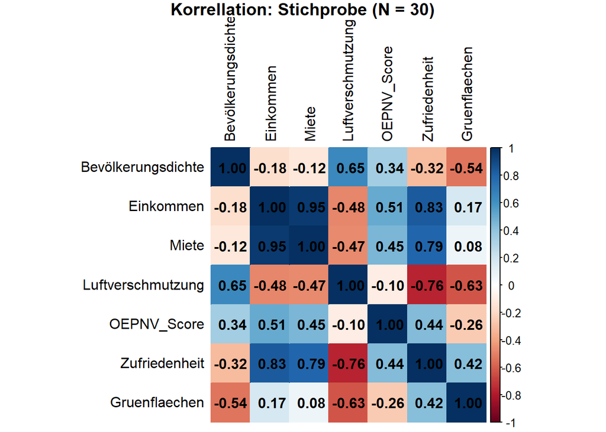

```r
corrplot(cor_mat, method = "color", addCoef.col = "black", tl.col = "black", title = "Korrellation: Stichprobe (N = 30)", mar = c(0,0,1,0))
```

```r
# Test mit Kaiser-Meyer-Olkin-Kriterium (Maß für die Eignung der Stichprobe)
# Werte über 0.5 gelten als akzeptabel, über 0.7 als gut.
kmo_test <- KMO(sample_df)
print(kmo_test$MSA)
```

```
## [1] 0.574841
```

Starke signifikante positive Korrelation zwischen Einkommen und Miete, Einkommen und Zufriedenheit, Miete und Zufriedenheit, Luftverschmutzung und Bevölkerungsdichte,

Starke signifikante negative Korrelation zwischen Luftverschmutzung und Zufriedenheit, Luftverschmutzung und Grünflächen.

### PCA und Scree-Plot

Wir führen hier vor der Faktorenanalyse eine PCA um herauszufinden, mit vielen Komponenten wir arbeiten sollten.

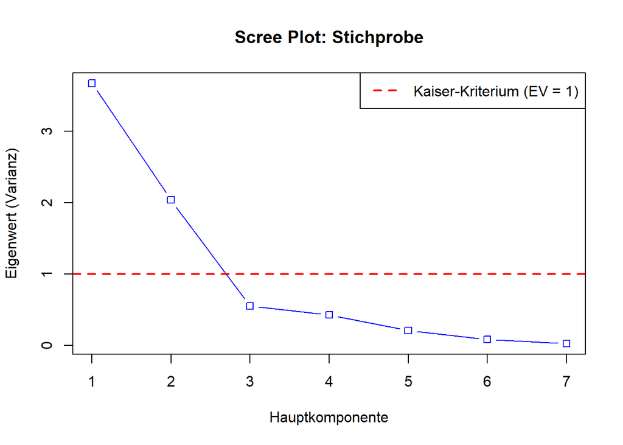

```r
# PCA for Scree Plot
pca_res <- prcomp(sample_df, center = TRUE, scale. = TRUE)

eigenvalues <- pca_res$sdev^2

plot(eigenvalues, type = "b", pch = 0.19, col = "blue",
     main = "Scree Plot: Stichprobe",
     xlab = "Hauptkomponente",
     ylab = "Eigenwert (Varianz)")
abline(h = 1, col="red", lty=2, lwd = 2) # Kaiser Criterion
legend("topright", legend = "Kaiser-Kriterium (EV = 1)", col = "red", lty = 2, lwd = 2)
```

Bei dem Elbogen hätten wir 2 Hauptkomponente.

### Faktorenanalyse

Eine Faktorenanalyse mit Varimax Rotation und dem Minimum-Residual-Ansatz (minres) um latenten Strukturen zu identifizieren.

Wir testen nun iterativ ein 2-Faktoren-Modell gegen ein 3-Faktoren-Modell und messen die Signifikanz anhand des RMSR (Root Mean Square Residual) und des p-Wertes des Modells.

```r
# Iteration 1: Das 2-Faktoren-Modell (MinRes)
fa_2 <- fa(sample_df, nfactors = 2, rotate = "varimax", fm = "minres")

# Iteration 2: Das 3-Faktoren-Modell (MinRes)
fa_3 <- fa(sample_df, nfactors = 3, rotate = "varimax", fm = "minres")

# Signifikanz und Modellgüte (Fit) vergleichen:
cat("\n--- MODELL-VERGLEICH ---\n")
```

```
##
## --- MODELL-VERGLEICH ---
```

```r
cat("2 Faktoren RMSR (kleiner ist besser):", round(fa_2$rms, 3), "\n")
```

```
## 2 Faktoren RMSR (kleiner ist besser): 0.05
```

```r
cat("3 Faktoren RMSR (kleiner ist besser):", round(fa_3$rms, 3), "\n")
```

```
## 3 Faktoren RMSR (kleiner ist besser): 0.02
```

```r
cat("2 Faktoren Tucker-Lewis Index (TLI, > 0.9 ist gut):", round(fa_2$TLI, 3), "\n")
```

```
## 2 Faktoren Tucker-Lewis Index (TLI, > 0.9 ist gut): 0.505
```

```r
# Statistische Signifikanz des 2-Faktor-Modells (p-Wert)
# Testet die Nullhypothese, dass 2 Faktoren ausreichen. (p > 0.05 ist hier GUT!)
cat("Signifikanz des 2-Faktor-Modells (p-Wert):", fa_2$PVAL, "\n")
```

```
## Signifikanz des 2-Faktor-Modells (p-Wert): 1.065288e-05
```

RMSR (0.05 vs. 0.02): Der Root Mean Square Residual misst den durchschnittlichen Fehler: der Wert von 0.05 beim 2-Faktoren-Modell ist gut. Dass er beim 3-Faktoren-Modell auf 0.02 sinkt, ist logisch: Je mehr Faktoren man hinzufügt, desto besser schmiegt sich das Modell an die Daten an.

TLI (0.505): Der Tucker-Lewis Index hat den Wert von 0.505 ist sehr niedrig. Das bedeutet: das Modell erklärt die Daten deutlich besser als ein Zufallsmodell, aber es gibt noch viel ungeklärte Struktur.

### Interpretation:

```r
print(fa_2$loadings, cutoff = 0.3)
```

```
##
## Loadings:
##                    MR1    MR2
## Bevölkerungsdichte         0.787
## Einkommen           0.940
## Miete               0.900
## Luftverschmutzung  -0.428  0.801
## OEPNV_Score         0.629  0.322
## Zufriedenheit       0.835 -0.471
## Gruenflaechen             -0.750
##
##                  MR1   MR2
## SS loadings    2.970 2.200
## Proportion Var 0.424 0.314
## Cumulative Var 0.424 0.739
```

Faktor/MR 1: Sozioökonomische Lebensqualität: Key Loadings: Einkommen (0.94), Miete(0.9), Zufriedenheit(0.84) und OEPNV_Score(0.63). Dieses Faktoren decken 42% der Varianz ab, und könnten sich so interpretieren lassen: Städte mit höheren Einkommen und Miete hätten auch “besseren” OEPNV und zufriedeneren BewöhnerInnen. Mit -0.43 bei Luftverschmutzung suggeriert, dass solche Städte auch wenig verschmutzt sind.

Faktor/MR 2: Ubarner Belastungsfaktor: Key Loadings: Luftverschmutzung (0.8), Bevölkerungsdichte(0.79), Gruenflaechen (-0.75) und Zufriedenheit (-0.47). Diese Faktoren repräsentieren die Kosten einer Stadt: Wir sehen, dass höhere Bevölkerungsdichte kommt häufig mit höherer Luftverschmutzung und weinigeren Gruenflaechen, welche die Zufriedenheit der EinwöhnerInnen senken.